# Auto1 Data Challenge

Tenzin Nyima

27 August 2018

**Aim**: to build a statistical model that best predicts the price of cars that’s in the best interest of Auto1’s business.

### Question 1 (10 Points)

List as many use cases for the dataset as possible. *Dataset “Auto1-DS-TestData.csv”: [available here](https://archive.ics.uci.edu/ml/datasets/Automobile)*

**Answer 1.** Various use cases for the dataset are as follows:

- predicting price as a function of the most relevant car features;
- keeping in consideration of the most informative positively/negatively correlated features while buying/selling a particular car, for example: predicting engine power (horsepower); mileage (city.mpg, highway.mpg); fuel type and cost-effectiveness; number of doors (height, width, and length); correlation of car dimensions to insurance; and the data-driven evidence for the correlation between car brand and price.

### Question 2 (10 Points)

Auto1 has a similar dataset (yet much larger…) Pick one of the use cases you listed in question 1 and describe how building a statistical model based on the dataset could best be used to improve Auto1’s business.

**Answer 2.** For this assignment, I’ll identify a model with the best predictors of car price. Auto1 could use this model as the estimators of car price while buying or selling cars.

### Question 3 (20 Points)

Implement the model you described in question 2 in R or Python. The code has to retrieve the data, train and test a statistical model, and report relevant performance criteria.

**Answer 3.** The following R script answers to question 3 in six sections. Each line of the script is followed by a comment that describes the intentions.

*(Note: this script was ran using R version 3.5.0 (2018-04-23))*

```r
library(caret)
library(psych)
library(corrplot)
library(pander)
```

### I. Data Handling

```r
# 1. Read the original data;
setwd("~/Documents/Auto1_DataChallenge/Data")
Auto1Data <- read.csv("Auto1-DS-TestData.csv", stringsAsFactors = FALSE)
dim(Auto1Data)
```

```
## [1] 205  26
```

```r
# 1a. Data structure;
pander(summary(Auto1Data))
```

Table continues below

| symboling | normalized.losses | make | fuel.type |
| --- | --- | --- | --- |
| Min. :-2.0000 | Length:205 | Length:205 | Length:205 |
| 1st Qu.: 0.0000 | Class :character | Class :character | Class :character |
| Median : 1.0000 | Mode :character | Mode :character | Mode :character |
| Mean : 0.8341 | NA | NA | NA |
| 3rd Qu.: 2.0000 | NA | NA | NA |
| Max. : 3.0000 | NA | NA | NA |

Table continues below

| aspiration | num.of.doors | body.style | drive.wheels |
| --- | --- | --- | --- |
| Length:205 | Length:205 | Length:205 | Length:205 |
| Class :character | Class :character | Class :character | Class :character |
| Mode :character | Mode :character | Mode :character | Mode :character |
| NA | NA | NA | NA |
| NA | NA | NA | NA |
| NA | NA | NA | NA |

Table continues below

| engine.location | wheel.base | length | width |
| --- | --- | --- | --- |
| Length:205 | Min. : 86.60 | Min. :141.1 | Min. :60.30 |
| Class :character | 1st Qu.: 94.50 | 1st Qu.:166.3 | 1st Qu.:64.10 |
| Mode :character | Median : 97.00 | Median :173.2 | Median :65.50 |
| NA | Mean : 98.76 | Mean :174.0 | Mean :65.91 |
| NA | 3rd Qu.:102.40 | 3rd Qu.:183.1 | 3rd Qu.:66.90 |
| NA | Max. :120.90 | Max. :208.1 | Max. :72.30 |

Table continues below

| height | curb.weight | engine.type | num.of.cylinders |
| --- | --- | --- | --- |
| Min. :47.80 | Min. :1488 | Length:205 | Length:205 |
| 1st Qu.:52.00 | 1st Qu.:2145 | Class :character | Class :character |
| Median :54.10 | Median :2414 | Mode :character | Mode :character |
| Mean :53.72 | Mean :2556 | NA | NA |
| 3rd Qu.:55.50 | 3rd Qu.:2935 | NA | NA |
| Max. :59.80 | Max. :4066 | NA | NA |

Table continues below

| engine.size | fuel.system | bore | stroke |
| --- | --- | --- | --- |
| Min. : 61.0 | Length:205 | Length:205 | Length:205 |
| 1st Qu.: 97.0 | Class :character | Class :character | Class :character |
| Median :120.0 | Mode :character | Mode :character | Mode :character |
| Mean :126.9 | NA | NA | NA |
| 3rd Qu.:141.0 | NA | NA | NA |
| Max. :326.0 | NA | NA | NA |

Table continues below

| compression.ratio | horsepower | peak.rpm | city.mpg |
| --- | --- | --- | --- |
| Min. : 7.00 | Length:205 | Length:205 | Min. :13.00 |
| 1st Qu.: 8.60 | Class :character | Class :character | 1st Qu.:19.00 |
| Median : 9.00 | Mode :character | Mode :character | Median :24.00 |
| Mean :10.14 | NA | NA | Mean :25.22 |
| 3rd Qu.: 9.40 | NA | NA | 3rd Qu.:30.00 |
| Max. :23.00 | NA | NA | Max. :49.00 |

| highway.mpg | price |
| --- | --- |
| Min. :16.00 | Length:205 |
| 1st Qu.:25.00 | Class :character |
| Median :30.00 | Mode :character |
| Mean :30.75 | NA |
| 3rd Qu.:34.00 | NA |
| Max. :54.00 | NA |

```r
str(Auto1Data)
```

```
## 'data.frame':    205 obs. of  26 variables:
##  $ symboling        : int  3 3 1 2 2 2 1 1 1 0 ...
##  $ normalized.losses: chr  "?" "?" "?" "164" ...
##  $ make             : chr  "alfa-romero" "alfa-romero" "alfa-romero" "audi" ...
##  $ fuel.type        : chr  "gas" "gas" "gas" "gas" ...
##  $ aspiration       : chr  "std" "std" "std" "std" ...
##  $ num.of.doors     : chr  "two" "two" "two" "four" ...
##  $ body.style       : chr  "convertible" "convertible" "hatchback" "sedan" ...
##  $ drive.wheels     : chr  "rwd" "rwd" "rwd" "fwd" ...
##  $ engine.location  : chr  "front" "front" "front" "front" ...
##  $ wheel.base       : num  88.6 88.6 94.5 99.8 99.4 ...
##  $ length           : num  169 169 171 177 177 ...
##  $ width            : num  64.1 64.1 65.5 66.2 66.4 66.3 71.4 71.4 71.4 67.9 ...
##  $ height           : num  48.8 48.8 52.4 54.3 54.3 53.1 55.7 55.7 55.9 52 ...
##  $ curb.weight      : int  2548 2548 2823 2337 2824 2507 2844 2954 3086 3053 ...
##  $ engine.type      : chr  "dohc" "dohc" "ohcv" "ohc" ...
##  $ num.of.cylinders : chr  "four" "four" "six" "four" ...
##  $ engine.size      : int  130 130 152 109 136 136 136 136 131 131 ...
##  $ fuel.system      : chr  "mpfi" "mpfi" "mpfi" "mpfi" ...
##  $ bore             : chr  "3.47" "3.47" "2.68" "3.19" ...
##  $ stroke           : chr  "2.68" "2.68" "3.47" "3.40" ...
##  $ compression.ratio: num  9 9 9 10 8 8.5 8.5 8.5 8.3 7 ...
##  $ horsepower       : chr  "111" "111" "154" "102" ...
##  $ peak.rpm         : chr  "5000" "5000" "5000" "5500" ...
##  $ city.mpg         : int  21 21 19 24 18 19 19 19 17 16 ...
##  $ highway.mpg      : int  27 27 26 30 22 25 25 25 20 22 ...
##  $ price            : chr  "13495" "16500" "16500" "13950" ...
```

```r
# 2. identify NAs;
Auto1Data[Auto1Data == "?"] <- NA
Auto1Data[Auto1Data == ""] <- NA

# 2a. omitting NAs;
# Reason: as a first run of the analysis with a full data;
Auto1Data <- na.omit(Auto1Data)
dim(Auto1Data)
```

```
## [1] 159  26
```

```r
# 3. Removing uninteresting/NA cols;
NACols  <- c("engine.location","fuel.system","engine.type")
# @Reasons: 1st - only one level; 2-3:error "rank-deficient fit";

# 3a. clean S1;
Auto1Data_1 <- Auto1Data[, -(match(NACols, colnames(Auto1Data)))]
dim(Auto1Data_1)
```

```
## [1] 159  23
```

```r
# str(Auto1Data_1)
# summary(Auto1Data_1)

# 3b. Convert numeric cols to numeric;
numCols <- c("symboling", "normalized.losses", "wheel.base", "length", "width", "height", "curb.weight", "engine.size", "bore","stroke", "compression.ratio", "horsepower", "peak.rpm", "city.mpg", "highway.mpg", "price")

for(i in seq(numCols)){
  Auto1Data_1[,numCols[i]] <- as.numeric(Auto1Data_1[,numCols[i]])
  }
# str(Auto1Data_1)
# summary(Auto1Data_1)

# 3c. Convert char cols to char;
charCols <- setdiff(colnames(Auto1Data_1), numCols)

# @crosscheck;
identical(ncol(Auto1Data_1), length(unique(c(numCols, charCols))))
```

```
## [1] TRUE
```

```r
# [1] TRUE;

for(i in seq(charCols)){
  Auto1Data_1[,charCols[i]] <- as.character(Auto1Data_1[,charCols[i]])
}
# str(Auto1Data_1)
# summary(Auto1Data_1)
```

```r
# 4. remove values with only one level;
# Note: to avoid errors due to such values;
charsObsCounts <- vector(mode = "list", length = length(charCols))
names(charsObsCounts) <- charCols

# 4a. identify those obs;
#S1: count values per level in each variable;
for (i in seq(charsObsCounts)) {
  charsObsCounts[[i]] <- table(factor(Auto1Data_1[,names(charsObsCounts)[i]],
                                      levels = unique(Auto1Data_1[,names(charsObsCounts)[i]])))
  }
#S2: in each variable, get index of levels with <=6 values;
charsObsCounts_1 <- lapply(charsObsCounts, function(x) which(x<=6))
#S2: variable names containing levels with <=6 values;
charsObsCounts_2 <- charsObsCounts_1[unlist(lapply(charsObsCounts_1, function(x) length(x) != 0))]
#S3: get indexes of values with <=6 values in each level;
charsObsCounts_2Ind <- vector("list", length = length(charsObsCounts_2))
for (i in seq(length(charsObsCounts_2))) {
  charsObsCounts_2Ind[[i]]<-which(!is.na(match(Auto1Data_1[,names(charsObsCounts_2)[i]], names(charsObsCounts_2[[i]]))))
}
#S4: final data, after removing rows with <=6 values in each level;
Auto1DataFin <- Auto1Data_1[-(unique(unlist(charsObsCounts_2Ind))), ]
dim(Auto1DataFin)
```

```
## [1] 124  23
```

```r
# [1] 124  23;
#S5: convert char cols into factors;
for (i in seq(charCols)) {
  Auto1DataFin[,charCols[i]] <- factor(Auto1DataFin[,charCols[i]], levels = unique(Auto1DataFin[,charCols[i]]))
}
#summary(Auto1DataFin)
#str(Auto1DataFin)
```

```r
# 5. Save data separately;

# @Y(targets);
Auto1DataFin_Y <- Auto1DataFin$price
length(Auto1DataFin_Y)
```

```
## [1] 124
```

```r
# @X(predictors);
Auto1DataFin_X <- Auto1DataFin[,-match("price", colnames(Auto1DataFin))]
dim(Auto1DataFin_X)
```

```
## [1] 124  22
```

### II. Exploratory Analysis

```r
# 1. summary statistics of raw data after omitting NAs;
pander(summary(Auto1Data))
```

Table continues below

| symboling | normalized.losses | make | fuel.type |
| --- | --- | --- | --- |
| Min. :-2.0000 | Length:159 | Length:159 | Length:159 |
| 1st Qu.: 0.0000 | Class :character | Class :character | Class :character |
| Median : 1.0000 | Mode :character | Mode :character | Mode :character |
| Mean : 0.7358 | NA | NA | NA |
| 3rd Qu.: 2.0000 | NA | NA | NA |
| Max. : 3.0000 | NA | NA | NA |

Table continues below

| aspiration | num.of.doors | body.style | drive.wheels |
| --- | --- | --- | --- |
| Length:159 | Length:159 | Length:159 | Length:159 |
| Class :character | Class :character | Class :character | Class :character |
| Mode :character | Mode :character | Mode :character | Mode :character |
| NA | NA | NA | NA |
| NA | NA | NA | NA |
| NA | NA | NA | NA |

Table continues below

| engine.location | wheel.base | length | width |
| --- | --- | --- | --- |
| Length:159 | Min. : 86.60 | Min. :141.1 | Min. :60.30 |
| Class :character | 1st Qu.: 94.50 | 1st Qu.:165.7 | 1st Qu.:64.00 |
| Mode :character | Median : 96.90 | Median :172.4 | Median :65.40 |
| NA | Mean : 98.26 | Mean :172.4 | Mean :65.61 |
| NA | 3rd Qu.:100.80 | 3rd Qu.:177.8 | 3rd Qu.:66.50 |
| NA | Max. :115.60 | Max. :202.6 | Max. :71.70 |

Table continues below

| height | curb.weight | engine.type | num.of.cylinders |
| --- | --- | --- | --- |
| Min. :49.40 | Min. :1488 | Length:159 | Length:159 |
| 1st Qu.:52.25 | 1st Qu.:2066 | Class :character | Class :character |
| Median :54.10 | Median :2340 | Mode :character | Mode :character |
| Mean :53.90 | Mean :2461 | NA | NA |
| 3rd Qu.:55.50 | 3rd Qu.:2810 | NA | NA |
| Max. :59.80 | Max. :4066 | NA | NA |

Table continues below

| engine.size | fuel.system | bore | stroke |
| --- | --- | --- | --- |
| Min. : 61.0 | Length:159 | Length:159 | Length:159 |
| 1st Qu.: 97.0 | Class :character | Class :character | Class :character |
| Median :110.0 | Mode :character | Mode :character | Mode :character |
| Mean :119.2 | NA | NA | NA |
| 3rd Qu.:135.0 | NA | NA | NA |
| Max. :258.0 | NA | NA | NA |

Table continues below

| compression.ratio | horsepower | peak.rpm | city.mpg |
| --- | --- | --- | --- |
| Min. : 7.00 | Length:159 | Length:159 | Min. :15.00 |
| 1st Qu.: 8.70 | Class :character | Class :character | 1st Qu.:23.00 |
| Median : 9.00 | Mode :character | Mode :character | Median :26.00 |
| Mean :10.16 | NA | NA | Mean :26.52 |
| 3rd Qu.: 9.40 | NA | NA | 3rd Qu.:31.00 |
| Max. :23.00 | NA | NA | Max. :49.00 |

| highway.mpg | price |
| --- | --- |
| Min. :18.00 | Length:159 |
| 1st Qu.:28.00 | Class :character |
| Median :32.00 | Mode :character |
| Mean :32.08 | NA |
| 3rd Qu.:37.00 | NA |
| Max. :54.00 | NA |

```r
str(Auto1Data)
```

```
## 'data.frame':    159 obs. of  26 variables:
##  $ symboling        : int  2 2 1 1 2 0 0 0 2 1 ...
##  $ normalized.losses: chr  "164" "164" "158" "158" ...
##  $ make             : chr  "audi" "audi" "audi" "audi" ...
##  $ fuel.type        : chr  "gas" "gas" "gas" "gas" ...
##  $ aspiration       : chr  "std" "std" "std" "turbo" ...
##  $ num.of.doors     : chr  "four" "four" "four" "four" ...
##  $ body.style       : chr  "sedan" "sedan" "sedan" "sedan" ...
##  $ drive.wheels     : chr  "fwd" "4wd" "fwd" "fwd" ...
##  $ engine.location  : chr  "front" "front" "front" "front" ...
##  $ wheel.base       : num  99.8 99.4 105.8 105.8 101.2 ...
##  $ length           : num  177 177 193 193 177 ...
##  $ width            : num  66.2 66.4 71.4 71.4 64.8 64.8 64.8 64.8 60.3 63.6 ...
##  $ height           : num  54.3 54.3 55.7 55.9 54.3 54.3 54.3 54.3 53.2 52 ...
##  $ curb.weight      : int  2337 2824 2844 3086 2395 2395 2710 2765 1488 1874 ...
##  $ engine.type      : chr  "ohc" "ohc" "ohc" "ohc" ...
##  $ num.of.cylinders : chr  "four" "five" "five" "five" ...
##  $ engine.size      : int  109 136 136 131 108 108 164 164 61 90 ...
##  $ fuel.system      : chr  "mpfi" "mpfi" "mpfi" "mpfi" ...
##  $ bore             : chr  "3.19" "3.19" "3.19" "3.13" ...
##  $ stroke           : chr  "3.40" "3.40" "3.40" "3.40" ...
##  $ compression.ratio: num  10 8 8.5 8.3 8.8 8.8 9 9 9.5 9.6 ...
##  $ horsepower       : chr  "102" "115" "110" "140" ...
##  $ peak.rpm         : chr  "5500" "5500" "5500" "5500" ...
##  $ city.mpg         : int  24 18 19 17 23 23 21 21 47 38 ...
##  $ highway.mpg      : int  30 22 25 20 29 29 28 28 53 43 ...
##  $ price            : chr  "13950" "17450" "17710" "23875" ...
##  - attr(*, "na.action")= 'omit' Named int  1 2 3 6 8 10 15 16 17 18 ...
##   ..- attr(*, "names")= chr  "1" "2" "3" "6" ...
```

```r
# 2. summary statistics of formatted data after omitting NAs;
pander(summary(Auto1DataFin))
```

Table continues below

| symboling | normalized.losses | make | fuel.type | aspiration |
| --- | --- | --- | --- | --- |
| Min. :-2.0000 | Min. : 65.0 | toyota :27 | gas :113 | std :105 |
| 1st Qu.: 0.0000 | 1st Qu.: 91.0 | nissan :17 | diesel: 11 | turbo: 19 |
| Median : 1.0000 | Median :106.0 | honda :13 | NA | NA |
| Mean : 0.5968 | Mean :116.7 | subaru :12 | NA | NA |
| 3rd Qu.: 1.0000 | 3rd Qu.:134.0 | mazda :11 | NA | NA |
| Max. : 3.0000 | Max. :256.0 | volvo :11 | NA | NA |
| NA | NA | (Other):33 | NA | NA |

Table continues below

| num.of.doors | body.style | drive.wheels | wheel.base | length |
| --- | --- | --- | --- | --- |
| two :47 | hatchback:47 | fwd:86 | Min. : 86.60 | Min. :144.6 |
| four:77 | sedan :62 | rwd:31 | 1st Qu.: 94.50 | 1st Qu.:165.3 |
| NA | wagon :15 | 4wd: 7 | Median : 96.50 | Median :171.7 |
| NA | NA | NA | Mean : 97.82 | Mean :171.2 |
| NA | NA | NA | 3rd Qu.: 99.50 | 3rd Qu.:176.2 |
| NA | NA | NA | Max. :109.10 | Max. :188.8 |
| NA | NA | NA | NA | NA |

Table continues below

| width | height | curb.weight | num.of.cylinders | engine.size |
| --- | --- | --- | --- | --- |
| Min. :62.5 | Min. :49.40 | Min. :1713 | four:113 | Min. : 79.0 |
| 1st Qu.:64.0 | 1st Qu.:52.58 | 1st Qu.:2039 | six : 11 | 1st Qu.: 97.0 |
| Median :65.4 | Median :54.10 | Median :2300 | NA | Median :109.0 |
| Mean :65.4 | Mean :53.89 | Mean :2401 | NA | Mean :115.2 |
| 3rd Qu.:66.5 | 3rd Qu.:55.50 | 3rd Qu.:2655 | NA | 3rd Qu.:122.0 |
| Max. :68.9 | Max. :59.80 | Max. :3296 | NA | Max. :181.0 |
| NA | NA | NA | NA | NA |

Table continues below

| bore | stroke | compression.ratio | horsepower |
| --- | --- | --- | --- |
| Min. :2.910 | Min. :2.190 | Min. : 7.00 | Min. : 52.00 |
| 1st Qu.:3.050 | 1st Qu.:3.150 | 1st Qu.: 8.70 | 1st Qu.: 69.00 |
| Median :3.215 | Median :3.280 | Median : 9.00 | Median : 85.00 |
| Mean :3.290 | Mean :3.228 | Mean :10.07 | Mean : 92.08 |
| 3rd Qu.:3.460 | 3rd Qu.:3.410 | 3rd Qu.: 9.40 | 3rd Qu.:107.25 |
| Max. :3.780 | Max. :3.900 | Max. :23.00 | Max. :200.00 |
| NA | NA | NA | NA |

| peak.rpm | city.mpg | highway.mpg | price |
| --- | --- | --- | --- |
| Min. :4150 | Min. :17.00 | Min. :22.00 | Min. : 5118 |
| 1st Qu.:4800 | 1st Qu.:24.00 | 1st Qu.:29.00 | 1st Qu.: 7295 |
| Median :5150 | Median :27.00 | Median :32.00 | Median : 8812 |
| Mean :5111 | Mean :27.12 | Mean :32.67 | Mean :10169 |
| 3rd Qu.:5425 | 3rd Qu.:31.00 | 3rd Qu.:37.00 | 3rd Qu.:11585 |
| Max. :6600 | Max. :49.00 | Max. :54.00 | Max. :22625 |
| NA | NA | NA | NA |

```r
str(Auto1DataFin)
```

```
## 'data.frame':    124 obs. of  23 variables:
##  $ symboling        : num  1 1 1 1 1 1 -1 3 2 2 ...
##  $ normalized.losses: num  118 118 118 148 148 148 110 145 137 137 ...
##  $ make             : Factor w/ 10 levels "dodge","honda",..: 1 1 1 1 1 1 1 1 2 2 ...
##  $ fuel.type        : Factor w/ 2 levels "gas","diesel": 1 1 1 1 1 1 1 1 1 1 ...
##  $ aspiration       : Factor w/ 2 levels "std","turbo": 1 1 2 1 1 1 1 2 1 1 ...
##  $ num.of.doors     : Factor w/ 2 levels "two","four": 1 1 1 2 2 2 2 1 1 1 ...
##  $ body.style       : Factor w/ 3 levels "hatchback","sedan",..: 1 1 1 1 2 2 3 1 1 1 ...
##  $ drive.wheels     : Factor w/ 3 levels "fwd","rwd","4wd": 1 1 1 1 1 1 1 1 1 1 ...
##  $ wheel.base       : num  93.7 93.7 93.7 93.7 93.7 ...
##  $ length           : num  157 157 157 157 157 ...
##  $ width            : num  63.8 63.8 63.8 63.8 63.8 63.8 64.6 66.3 63.9 63.9 ...
##  $ height           : num  50.8 50.8 50.8 50.6 50.6 50.6 59.8 50.2 50.8 50.8 ...
##  $ curb.weight      : num  1876 1876 2128 1967 1989 ...
##  $ num.of.cylinders : Factor w/ 2 levels "four","six": 1 1 1 1 1 1 1 1 1 1 ...
##  $ engine.size      : num  90 90 98 90 90 90 122 156 92 92 ...
##  $ bore             : num  2.97 2.97 3.03 2.97 2.97 2.97 3.34 3.6 2.91 2.91 ...
##  $ stroke           : num  3.23 3.23 3.39 3.23 3.23 3.23 3.46 3.9 3.41 3.41 ...
##  $ compression.ratio: num  9.41 9.4 7.6 9.4 9.4 9.4 8.5 7 9.6 9.2 ...
##  $ horsepower       : num  68 68 102 68 68 68 88 145 58 76 ...
##  $ peak.rpm         : num  5500 5500 5500 5500 5500 5500 5000 5000 4800 6000 ...
##  $ city.mpg         : num  37 31 24 31 31 31 24 19 49 31 ...
##  $ highway.mpg      : num  41 38 30 38 38 38 30 24 54 38 ...
##  $ price            : num  5572 6377 7957 6229 6692 ...
```

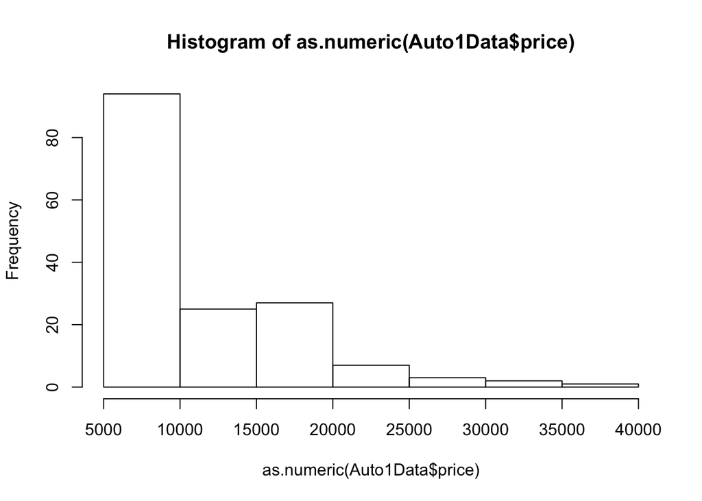

```r
# 3. check the distribution of raw, cleaned and log transformed prices;
hist(as.numeric(Auto1Data$price))
```

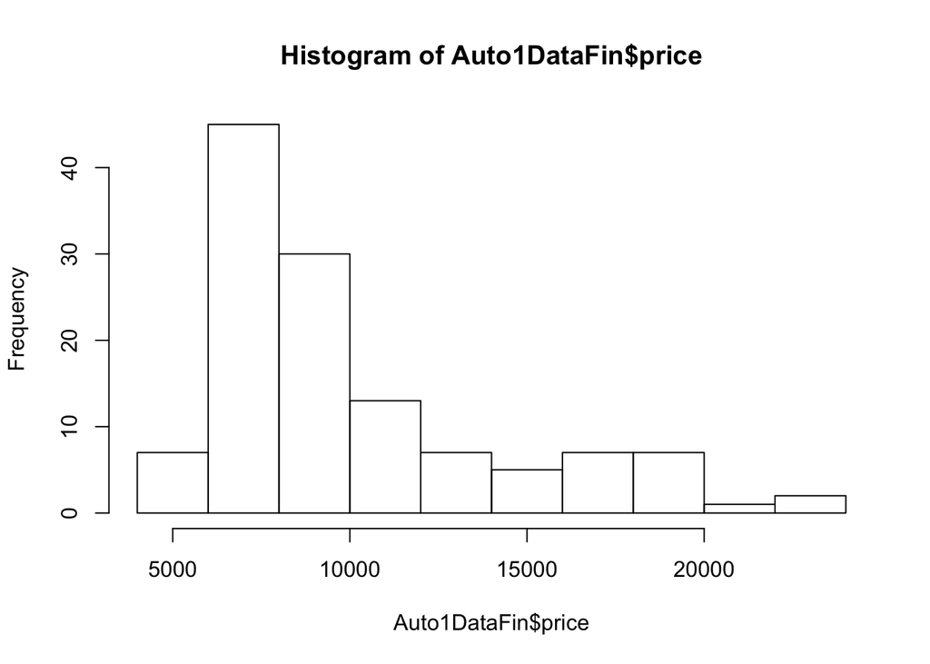

```r
hist(Auto1DataFin$price)
```

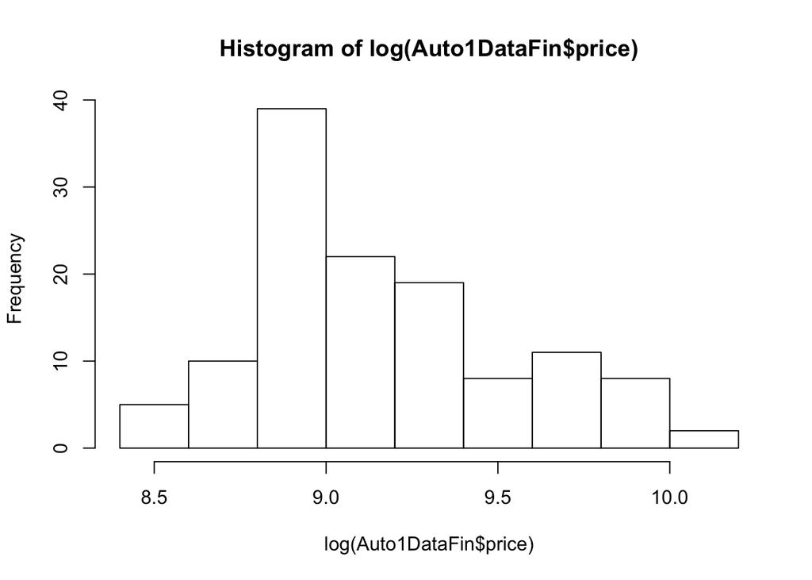

```r
hist(log(Auto1DataFin$price))
```

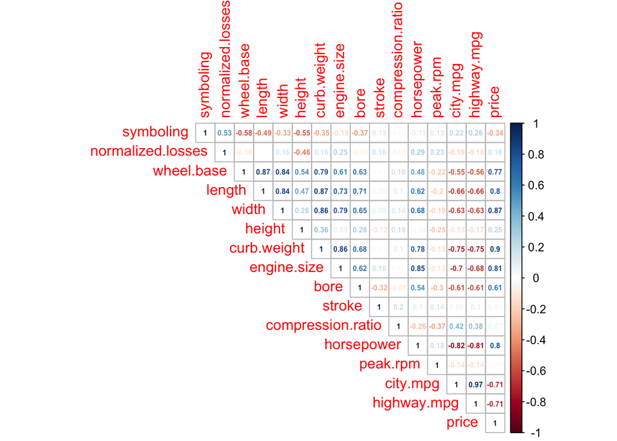

```r
# 4. correlation between price and the predictors;
Auto1DataFin_Cor <- corr.test(Auto1DataFin[,names(which(sapply(Auto1DataFin, function(x) is.numeric(x))))],
                              method="pearson", adjust="BH")

# @visualize;
corrplot(Auto1DataFin_Cor$r, method = "number", type = "upper", number.cex = .5)
```

### III. Fitting Models

```r
# @Y(targets);
# length(Auto1DataFin_Y)
# [1] 124;
# @X(predictors);
# dim(Auto1DataFin_X)
# [1] 124  22;

# 1. To fit models with similar training and test splits, set up the train control object;
Auto1DataFin_TrCont <- trainControl(method = "cv", number = 10, verboseIter = TRUE)
```

```r
# 2. Generalized Linear Model;

# 2.1 without preprocessing;
set.seed(72)
Auto1DataFin_GLM <- train(x = Auto1DataFin_X, y = Auto1DataFin_Y,
                          method = "glm",
                          trControl = Auto1DataFin_TrCont)
Auto1DataFin_GLM$results$RMSE
```

```
## [1] 1542.653
```

```r
# 2.2 preprocessing 1;
set.seed(72)
Auto1DataFin_GLM_pp1 <- train(x = Auto1DataFin_X, y = Auto1DataFin_Y,
                          method = "glm",
                          trControl = Auto1DataFin_TrCont,
                          preProcess = c("zv", "center", "scale", "pca"))
Auto1DataFin_GLM_pp1$results$RMSE
```

```
## [1] 1490.604
```

```r
# 2.3 preprocessing 2;
set.seed(72)
Auto1DataFin_GLM_pp2 <- train(x = Auto1DataFin_X, y = Auto1DataFin_Y,
                              method = "glm",
                              trControl = Auto1DataFin_TrCont,
                              preProcess = c("zv", "center", "scale", "spatialSign"))
Auto1DataFin_GLM_pp2$results$RMSE
```

```
## [1] 1492.925
```

```r
# 3. Random Forest;
RF_Mtry <- data.frame(mtry=1:15)
set.seed(72)
Auto1DataFin_RF <- train(x = Auto1DataFin_X, y = Auto1DataFin_Y,
                         tuneGrid = RF_Mtry, method = "rf",
                         trControl = Auto1DataFin_TrCont)
```

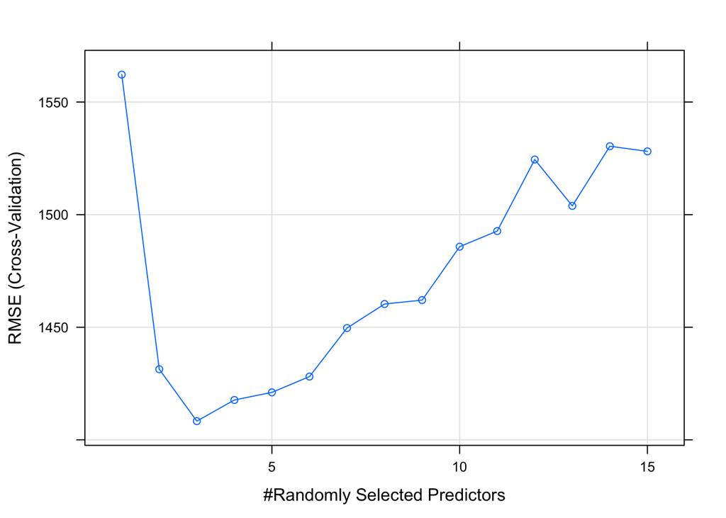

```r
plot(Auto1DataFin_RF)
```